# Flume Runs: 10/18/17 and 10/20/17

Justin Nghiem

10/26/17

*Source files* ⇒ LISST_floc.Rmd ⇒ C:_values.rds

### Flume run on 10/18/17

- sediment: Aquatic Park (collected 10/1/17) and floc (kaolinite, NaCl)
- start collection:
- end collection:
- start flume:
- frequency: 30 Hz
- flux: 216 US gal/min
- water depth: 45 cm
- slope: 0.00%

#### Notes:

- floc was prepared in a concentrated mixture, then added close to the flume bed in the test section downstream of LISST device
- floc included 155.5 g of kaolinite and 31.1 g of NaCl
- some floc settled in the test bed where the mixture was added; otherwise, little settling

The dataset has been processed to remove samples with optical transmission less than 0.1 or greater than 0.995. The plots of the densities use 10-minute time intervals (“groups”).

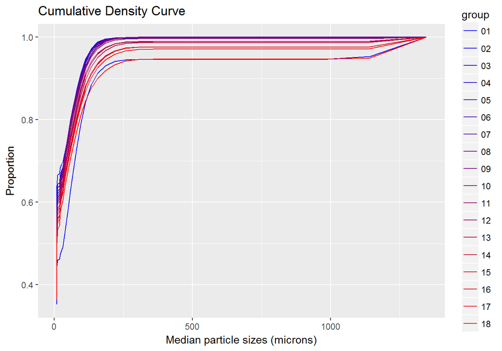

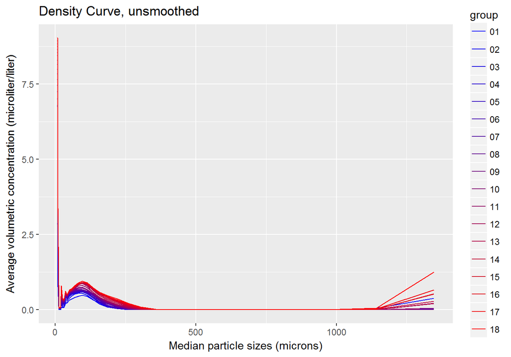

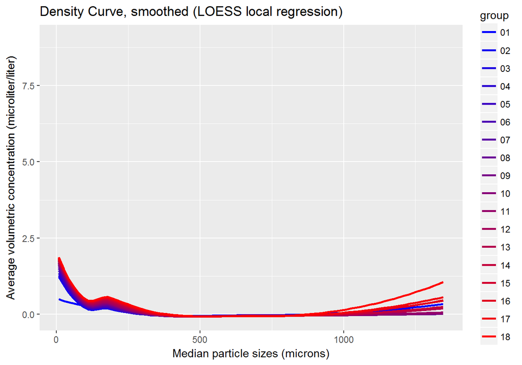

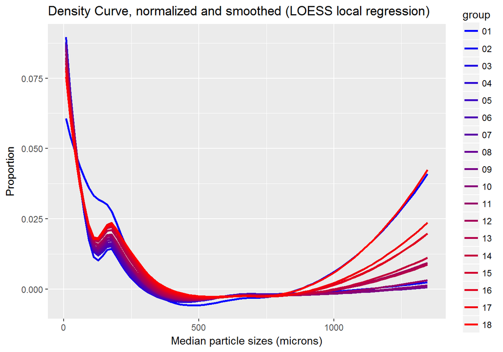

```
## [1] "Number of samples is 10802"
```

| group | avg_size |
| --- | --- |
| 1 | 181.71595 |
| 2 | 217.03710 |
| 3 | 245.79340 |
| 4 | 251.00680 |
| 5 | 235.37850 |
| 6 | 96.65208 |
| 7 | 152.52700 |
| 8 | 43.02672 |
| 9 | 26.40669 |
| 10 | 157.63391 |
| 11 | 36.06408 |
| 12 | 26.13159 |
| 13 | 64.81842 |
| 14 | 38.97154 |
| 15 | 27.31984 |
| 16 | 39.28531 |
| 17 | 38.52031 |
| 18 | 29.20936 |
| 19 | 33.88527 |
| 20 | 37.84185 |
| 21 | 31.32410 |
| 22 | 33.01019 |
| 23 | 37.79801 |
| 24 | 32.73733 |
| 25 | 32.68576 |
| 26 | 34.91625 |
| 27 | 33.61600 |
| 28 | 37.71695 |
| 29 | 34.39425 |
| 30 | 34.00083 |

[output cut: 150 more lines]

`group` denotes the time interval. For example, `group` 1 is the time from the start of the experiment with a length of the time interval. `avg_size` is the mean particle size in microns. In the table above, time intervals are 1-minute. The plot of the table is:

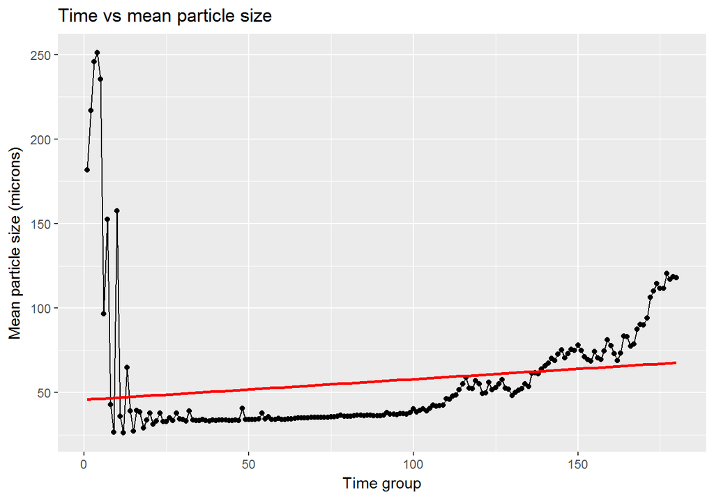

The `mean` of mean particle sizes is 56.8219365. The `standard deviation` of mean particle sizes is 37.9027686. The $R^2$ value is 0.0281105

### Flume run on 10/20/17

- sediment: same as 10/18 run
- start collection: 11:37am
- end collection: 2:37pm
- start flume: 11:42am
- frequency: 10 Hz
- flux: 67 US gal/min
- water depth: 45 cm
- slope: 0.00%

#### Notes

- turbid water before the run, most likely floc still in suspension from the previous run on 10/18
- opening to sensor aligned parallel to flow
- some sediment trapped under the false bed in the test section

The dataset has been processed to remove samples with optical transmission less than 0.1 or greater than 0.995. The plots of the densities use 10-minute time intervals (“groups”).

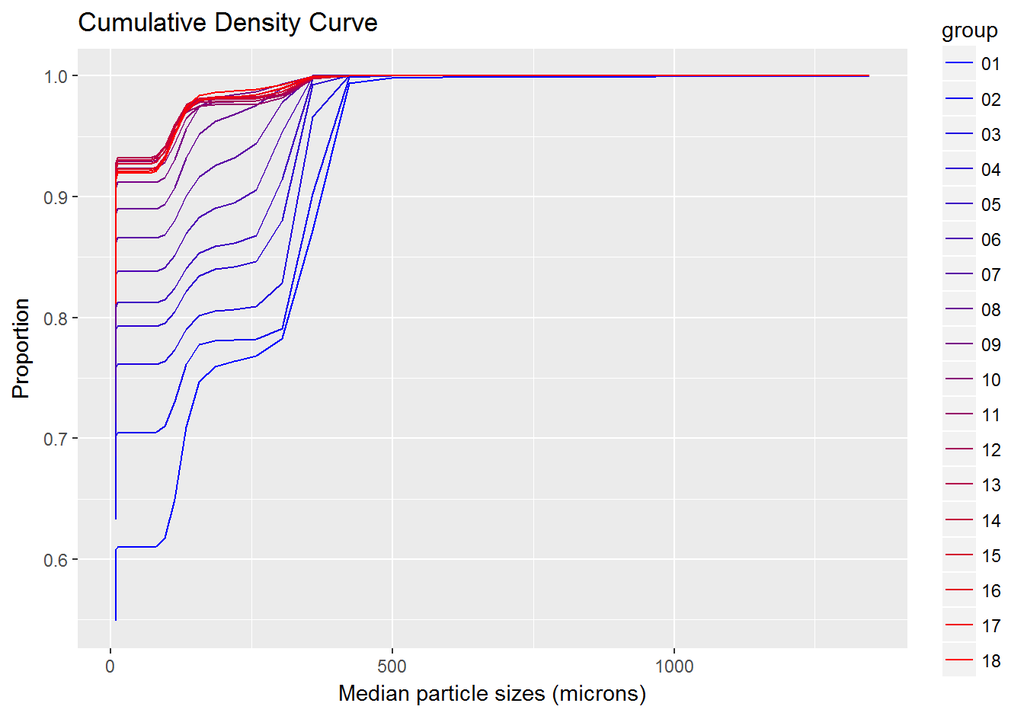

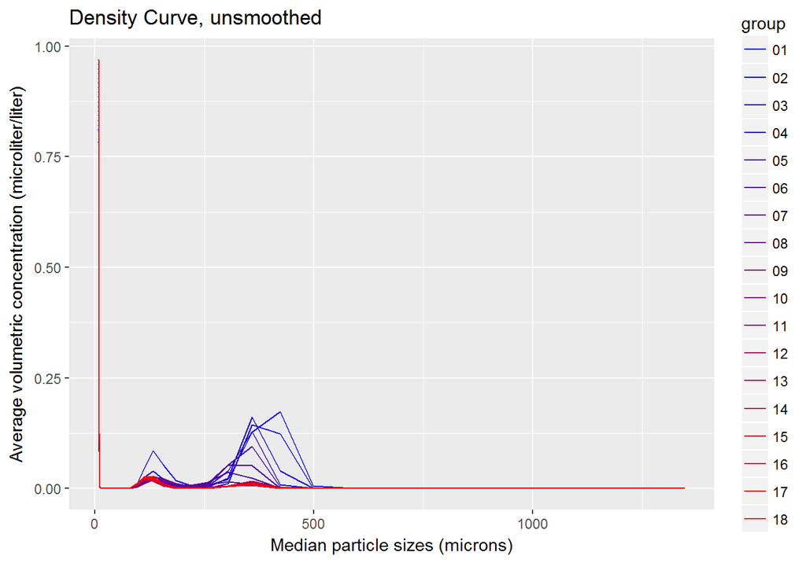

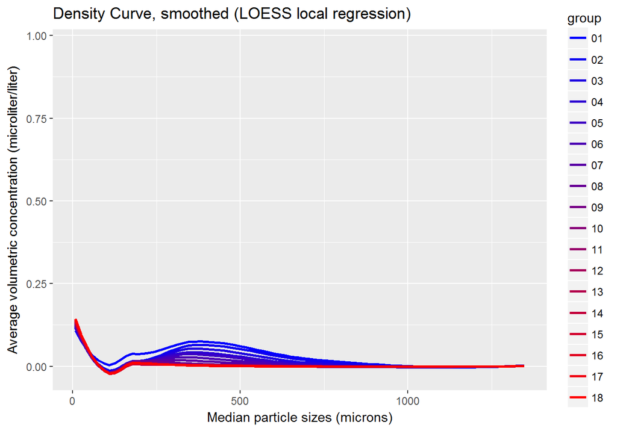

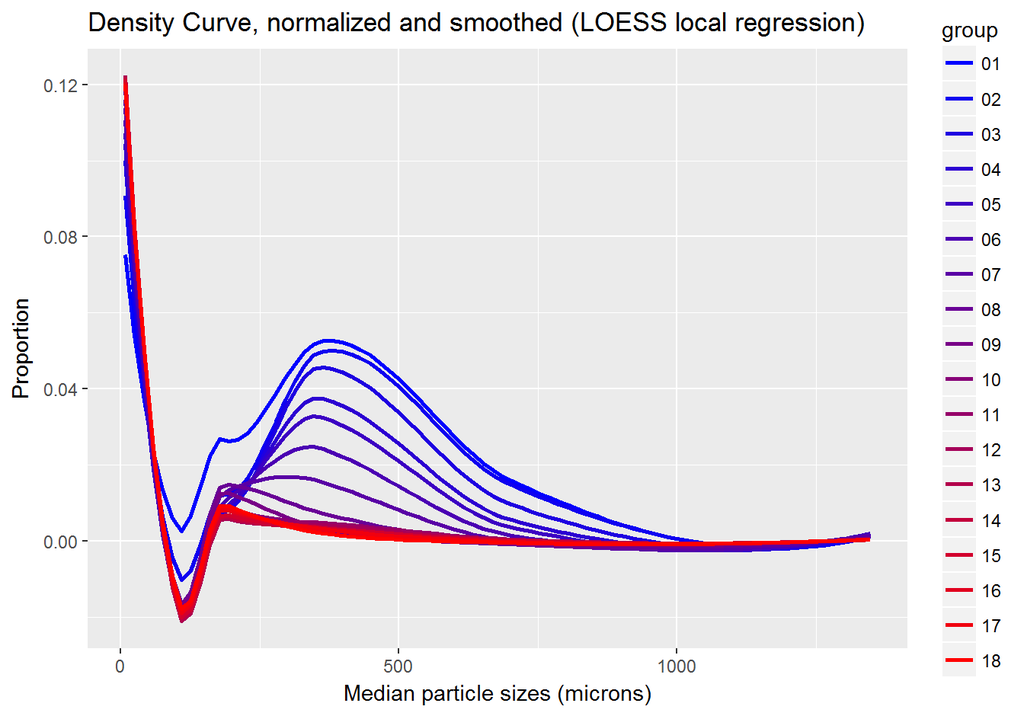

```
## [1] "Number of samples is 10802"
```

| group | avg_size |
| --- | --- |
| 1 | 118.69511 |
| 2 | 115.89371 |
| 3 | 117.40884 |
| 4 | 112.52509 |
| 5 | 113.15546 |
| 6 | 120.90717 |
| 7 | 121.74913 |
| 8 | 121.11569 |
| 9 | 134.19528 |
| 10 | 114.50780 |
| 11 | 108.90241 |
| 12 | 101.61057 |
| 13 | 106.35852 |
| 14 | 107.04848 |
| 15 | 102.01140 |
| 16 | 97.22197 |
| 17 | 95.00973 |
| 18 | 94.15989 |
| 19 | 93.31907 |
| 20 | 90.75466 |
| 21 | 88.21402 |
| 22 | 87.22216 |
| 23 | 88.42367 |
| 24 | 86.59483 |
| 25 | 84.68754 |
| 26 | 81.77772 |
| 27 | 79.02777 |
| 28 | 77.95434 |
| 29 | 76.23236 |
| 30 | 74.60047 |

[output cut: 150 more lines]

In the table above, time intervals are 1-minute. The plot of the table is:

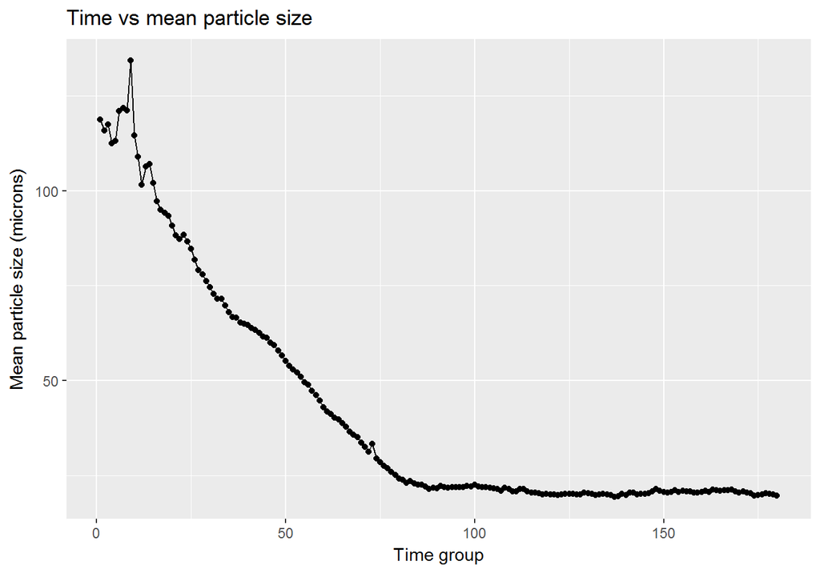

The `mean` of mean particle sizes is 41.917852. The `standard deviation` of mean particle sizes is 30.573151.